# Biostatistics HW1

吴嘉骜 21307130203

2024-3-18

## Cardiovascular Disease (Problems 2.47-2.50)

```r
data <- read_excel("LMV.xlsx")

arithmetic_means <- data %>%
  group_by(bpcat) %>%
  summarise(arithmetic_mean_LVMI = mean(lvmht27))

print(arithmetic_means)
```

```
## # A tibble: 3 × 2
##   bpcat arithmetic_mean_LVMI
##   <dbl>                <dbl>
## 1     1                 29.3
## 2     2                 33.8
## 3     3                 34.1
```

```r
geometric_means <- data %>%
  group_by(bpcat) %>%
  summarise(geometric_mean_LVMI = exp(mean(log(lvmht27))))

print(geometric_means)
```

```
## # A tibble: 3 × 2
##   bpcat geometric_mean_LVMI
##   <dbl>               <dbl>
## 1     1                28.6
## 2     2                33.3
## 3     3                32.9
```

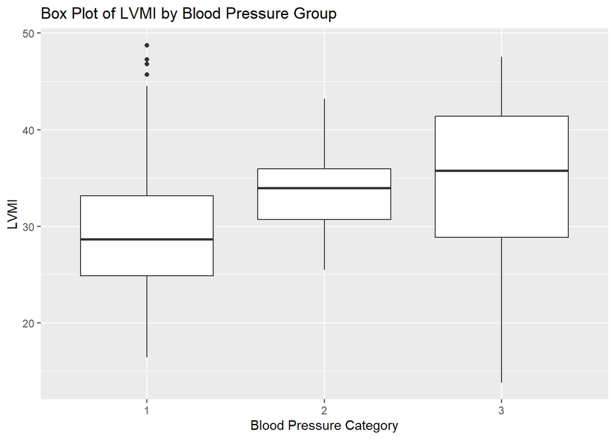

```r
ggplot(data, aes(x = factor(bpcat), y = lvmht27)) +
  geom_boxplot() +
  xlab("Blood Pressure Category") +
  ylab("LVMI") +
  ggtitle("Box Plot of LVMI by Blood Pressure Group")
```

From the box plot, we observe that the distribution from bp category 1 is slightly positively skewed with some outliers, the distribution from bp 2 is negatively skewed, and the distribution from bp 3 is also slightly negatively skewed.

Considering that the distribution is relatively symmetrical, and the presence of outliers is not significant; therefore, the **arithmetic mean** could be reasonably representative of the center of each blood pressure group for this type of data.

## Infectious Disease (Problems 3.28-3.31)

### 3.28

To find the probability that at least one child among the three will get influenza, we calculate the complement of the probability that none of the children get influenza.

$$\begin{align*}
P(\text{At least one gets sick})
&= 1 - P(\text{None get sick}) \\
&= 1 - (1 - 3.78\%) (1 - 1.70\%)^2 \\
&= 1 - 92.98\% \\
&= 7.02\%
\end{align*}$$

### 3.29

Let $P(\text{flu34})$ be the probability of a 3–4-year-old child in the village that gets influenza.

Let $P(\text{vac34})$ be the probability of a 3–4-year-old child in the village that gets vaccinated.
$$\begin{align*}
P(\text{flu34}) &= P(\text{flu34|vac34}) \times P(\text{vac34}) +
P(\text{flu34|not vac34}) \times P(\text{not vac34})\\
&= 3.78\% \times 80\% + 5.69 \% \times 2 \times 20\% \\
&= 5.3 \%
\end{align*}$$

### 3.30

Similarly,

$$\begin{align*}
P(\text{flu58}) &= P(\text{flu58|vac58}) \times P(\text{vac58}) +
P(\text{flu58|not vac58}) \times P(\text{not vac58})\\
&= 1.70\% \times 70\% + 5.15\% \times 2 \times 30\% \\
&= 4.28 \%
\end{align*}$$

### 3.31

To find the probability that a 5–8-year-old child with influenza was vaccinated, we apply Bayes’ theorem.

Let $P(\text{vac|flu58})$ be the probability that the child was vaccinated given they are sick.

Using Bayes’ theorem:

$$\begin{align*}
P(\text{vac|flu58}) &= \frac{P(\text{flu58|vac58}) \times
P(\text{vac58})}{P(\text{flu58})} \\
&= \frac{1.70\% \times 70\%}{4.28\%} \\
&= 27.80\%
\end{align*}$$